# Company Bankruptcy Prediction

Ardian the Great

August 18, 2023

### Import used libraries

```r
library(dplyr)
library(GGally)
library(reshape2)
library(caret)
library(FactoMineR)
library(factoextra)
library(class)
library(Ardian) # My personal Package
```

### Read the data

```r
companies <- read.csv('datasets/companies.csv')
```

### **Inspect the data**

#### Top 6 rows

```r
companies %>% head()
```

|  | Bankrupt. | ROA.C..before.interest.and.depreciation.before.interest | ROA.A..before.interest.and...after.tax | ROA.B..before.interest.and.depreciation.after.tax | Operating.Gross.Margin | Realized.Sales.Gross.Margin | Operating.Profit.Rate | Pre.tax.net.Interest.Rate | After.tax.net.Interest.Rate | Non.industry.income.and.expenditure.revenue | Continuous.interest.rate..after.tax. | Operating.Expense.Rate | Research.and.development.expense.rate | Cash.flow.rate | Interest.bearing.debt.interest.rate | Tax.rate..A. | Net.Value.Per.Share..B. | Net.Value.Per.Share..A. | Net.Value.Per.Share..C. | Persistent.EPS.in.the.Last.Four.Seasons | Cash.Flow.Per.Share | Revenue.Per.Share..Yuan... | Operating.Profit.Per.Share..Yuan... | Per.Share.Net.profit.before.tax..Yuan... | Realized.Sales.Gross.Profit.Growth.Rate | Operating.Profit.Growth.Rate | After.tax.Net.Profit.Growth.Rate | Regular.Net.Profit.Growth.Rate | Continuous.Net.Profit.Growth.Rate | … |
| --- | --- | --- | --- | --- | --- | --- | --- | --- | --- | --- | --- | --- | --- | --- | --- | --- | --- | --- | --- | --- | --- | --- | --- | --- | --- | --- | --- | --- | --- | --- |
| 1 | 1 | 0.3705943 | 0.4243894 | 0.4057498 | 0.6014572 | 0.6014572 | 0.9989692 | 0.7968871 | 0.8088094 | 0.3026464 | 0.7809849 | 1.256969e-04 | 0 | 0.4581431 | 0.0007250725 | 0 | 0.1479499 | 0.1479499 | 0.1479499 | 0.1691406 | 0.3116644 | 0.017559780 | 0.09592053 | 0.1387362 | 0.02210228 | 0.8481950 | 0.6889795 | 0.6889795 | 0.2175354 | … |
| 2 | 1 | 0.4642909 | 0.5382141 | 0.5167300 | 0.6102351 | 0.6102351 | 0.9989460 | 0.7973802 | 0.8093007 | 0.3035564 | 0.7815060 | 2.897851e-04 | 0 | 0.4618673 | 0.0006470647 | 0 | 0.1822511 | 0.1822511 | 0.1822511 | 0.2089439 | 0.3181368 | 0.021144335 | 0.09372201 | 0.1699179 | 0.02208017 | 0.8480879 | 0.6896929 | 0.6897017 | 0.2176196 | … |
| 3 | 1 | 0.4260713 | 0.4990188 | 0.4722951 | 0.6014500 | 0.6013635 | 0.9988574 | 0.7964034 | 0.8083875 | 0.3020352 | 0.7802839 | 2.361297e-04 | 25500000 | 0.4585206 | 0.0007900790 | 0 | 0.1779107 | 0.1779107 | 0.1937129 | 0.1805805 | 0.3071019 | 0.005944008 | 0.09233776 | 0.1428033 | 0.02276010 | 0.8480940 | 0.6894627 | 0.6894697 | 0.2176013 | … |
| 4 | 1 | 0.3998440 | 0.4512647 | 0.4577333 | 0.5835411 | 0.5835411 | 0.9986997 | 0.7969670 | 0.8089656 | 0.3033495 | 0.7812410 | 1.078888e-04 | 0 | 0.4657054 | 0.0004490449 | 0 | 0.1541865 | 0.1541865 | 0.1541865 | 0.1937222 | 0.3216736 | 0.014368468 | 0.07776240 | 0.1486028 | 0.02204607 | 0.8480055 | 0.6891095 | 0.6891095 | 0.2175682 | … |
| 5 | 1 | 0.4650222 | 0.5384322 | 0.5222978 | 0.5987835 | 0.5987835 | 0.9989731 | 0.7973661 | 0.8093037 | 0.3034750 | 0.7815500 | 7.890000e+09 | 0 | 0.4627463 | 0.0006860686 | 0 | 0.1675024 | 0.1675024 | 0.1675024 | 0.2125366 | 0.3191625 | 0.029689792 | 0.09689765 | 0.1684115 | 0.02209591 | 0.8482582 | 0.6896969 | 0.6896969 | 0.2176256 | … |
| 6 | 1 | 0.3886803 | 0.4151766 | 0.4191338 | 0.5901714 | 0.5902507 | 0.9987581 | 0.7969032 | 0.8087706 | 0.3031158 | 0.7810691 | 1.571500e-04 | 0 | 0.4658615 | 0.0007160716 | 0 | 0.1555771 | 0.1555771 | 0.1555771 | 0.1744351 | 0.3253873 | 0.018104270 | 0.07808810 | 0.1388115 | 0.02156494 | 0.8479828 | 0.6891051 | 0.6891775 | 0.2175664 | … |

#### Bottom 6 rows

```r
companies %>% tail()
```

|  | Bankrupt. | ROA.C..before.interest.and.depreciation.before.interest | ROA.A..before.interest.and...after.tax | ROA.B..before.interest.and.depreciation.after.tax | Operating.Gross.Margin | Realized.Sales.Gross.Margin | Operating.Profit.Rate | Pre.tax.net.Interest.Rate | After.tax.net.Interest.Rate | Non.industry.income.and.expenditure.revenue | Continuous.interest.rate..after.tax. | Operating.Expense.Rate | Research.and.development.expense.rate | Cash.flow.rate | Interest.bearing.debt.interest.rate | Tax.rate..A. | Net.Value.Per.Share..B. | Net.Value.Per.Share..A. | Net.Value.Per.Share..C. | Persistent.EPS.in.the.Last.Four.Seasons | Cash.Flow.Per.Share | Revenue.Per.Share..Yuan... | Operating.Profit.Per.Share..Yuan... | Per.Share.Net.profit.before.tax..Yuan... | Realized.Sales.Gross.Profit.Growth.Rate | Operating.Profit.Growth.Rate | After.tax.Net.Profit.Growth.Rate | Regular.Net.Profit.Growth.Rate | Continuous.Net.Profit.Growth.Rate | … |
| --- | --- | --- | --- | --- | --- | --- | --- | --- | --- | --- | --- | --- | --- | --- | --- | --- | --- | --- | --- | --- | --- | --- | --- | --- | --- | --- | --- | --- | --- | --- |
| 6814 | 0 | 0.4775996 | 0.5311273 | 0.5260988 | 0.5958287 | 0.5958575 | 0.9989048 | 0.7973755 | 0.8092940 | 0.3036343 | 0.7815534 | 1.002568e-04 | 7.030000e+09 | 0.4639877 | 3.560356e-04 | 0.0000000 | 0.1806498 | 0.1806498 | 0.1806498 | 0.2132930 | 0.3219566 | 0.0242600239 | 0.08891784 | 0.1695413 | 0.02236178 | 0.8481275 | 0.6896853 | 0.6896853 | 0.2176266 | … |
| 6815 | 0 | 0.4936869 | 0.5394679 | 0.5432304 | 0.6044552 | 0.6044624 | 0.9989921 | 0.7974090 | 0.8093311 | 0.3035103 | 0.7815878 | 1.510213e-04 | 4.500000e+09 | 0.4637343 | 1.790179e-04 | 0.1133718 | 0.1750453 | 0.1750453 | 0.1750453 | 0.2166021 | 0.3209663 | 0.0207662175 | 0.09820047 | 0.1721021 | 0.02237376 | 0.8482045 | 0.6897781 | 0.6897781 | 0.2176353 | … |
| 6816 | 0 | 0.4751621 | 0.5382686 | 0.5241715 | 0.5983078 | 0.5983078 | 0.9989922 | 0.7974144 | 0.8093273 | 0.3035197 | 0.7815861 | 5.220000e+09 | 1.440000e+09 | 0.4619780 | 2.370237e-04 | 0.3715963 | 0.1813240 | 0.1813240 | 0.1813240 | 0.2166966 | 0.3182783 | 0.0230500476 | 0.09860761 | 0.1727800 | 0.02215937 | 0.8482448 | 0.6897340 | 0.6897340 | 0.2176314 | … |
| 6817 | 0 | 0.4727246 | 0.5337440 | 0.5206381 | 0.6104441 | 0.6102135 | 0.9989845 | 0.7974009 | 0.8093169 | 0.3035122 | 0.7815464 | 2.509312e-04 | 1.039086e-04 | 0.4721891 | 0.000000e+00 | 0.4908392 | 0.2695209 | 0.2695209 | 0.2695209 | 0.2109294 | 0.3248568 | 0.0442548815 | 0.10007328 | 0.1732319 | 0.02206835 | 0.8479776 | 0.6892021 | 0.6892021 | 0.2175472 | … |
| 6818 | 0 | 0.5062643 | 0.5599106 | 0.5540446 | 0.6078496 | 0.6078496 | 0.9990738 | 0.7974999 | 0.8093994 | 0.3034982 | 0.7816633 | 1.236154e-04 | 2.510000e+09 | 0.4761229 | 2.110211e-04 | 0.1812937 | 0.2133918 | 0.2133918 | 0.2133918 | 0.2283256 | 0.3465728 | 0.0315350061 | 0.11179871 | 0.1855841 | 0.02234993 | 0.8540638 | 0.6961128 | 0.6961128 | 0.2180056 | … |
| 6819 | 0 | 0.4930532 | 0.5701047 | 0.5495476 | 0.6274089 | 0.6274089 | 0.9980803 | 0.8019867 | 0.8137996 | 0.3134153 | 0.7860790 | 1.431695e-03 | 0.000000e+00 | 0.4277212 | 5.900000e+08 | 0.0000000 | 0.2207661 | 0.2207661 | 0.2207661 | 0.2277583 | 0.3057933 | 0.0006654869 | 0.09250061 | 0.1821195 | 0.02531588 | 0.8480531 | 0.6895266 | 0.6895266 | 0.2176049 | … |

## **Data Pre-processing**

```r
companies %>% duplicated() %>% any()
```

```
## [1] FALSE
```

> Alhamdulillah, there are no duplicated rows

### Check missing values

```r
companies %>% anyNA()
```

```
## [1] FALSE
```

> Alhamdulillah, there are no missing values

### Inspect data structure

```r
companies %>% glimpse()
```

```
## Rows: 6,819
## Columns: 96
## $ Bankrupt.                                               <int> 1, 1, 1, 1, 1,…
## $ ROA.C..before.interest.and.depreciation.before.interest <dbl> 0.3705943, 0.4…
## $ ROA.A..before.interest.and...after.tax                  <dbl> 0.4243894, 0.5…
## $ ROA.B..before.interest.and.depreciation.after.tax       <dbl> 0.4057498, 0.5…
## $ Operating.Gross.Margin                                  <dbl> 0.6014572, 0.6…
## $ Realized.Sales.Gross.Margin                             <dbl> 0.6014572, 0.6…
## $ Operating.Profit.Rate                                   <dbl> 0.9989692, 0.9…
## $ Pre.tax.net.Interest.Rate                               <dbl> 0.7968871, 0.7…
## $ After.tax.net.Interest.Rate                             <dbl> 0.8088094, 0.8…
## $ Non.industry.income.and.expenditure.revenue             <dbl> 0.3026464, 0.3…
## $ Continuous.interest.rate..after.tax.                    <dbl> 0.7809849, 0.7…
## $ Operating.Expense.Rate                                  <dbl> 1.256969e-04, …
## $ Research.and.development.expense.rate                   <dbl> 0.00e+00, 0.00…
```

[output cut: 83 more lines]

> Wow, so many columns

### Parse categorical columns

```r
companies <- companies %>%
  mutate_at(vars(Bankrupt., Liability.Assets.Flag, Net.Income.Flag), as.factor)
```

### Check categorical columns summary

```r
companies %>% select_if(is.factor) %>% summary()
```

```
##  Bankrupt. Liability.Assets.Flag Net.Income.Flag
##  0:6599    0:6811                1:6819
##  1: 220    1:   8
```

> Turns out they’re near zero variance, I’ll just remove them.

> And about the target proportion, I’ll talk about it

### Remove near zero variance columns

```r
companies <- companies %>% select(-Net.Income.Flag, -Liability.Assets.Flag)
```

### Check target variable proportion

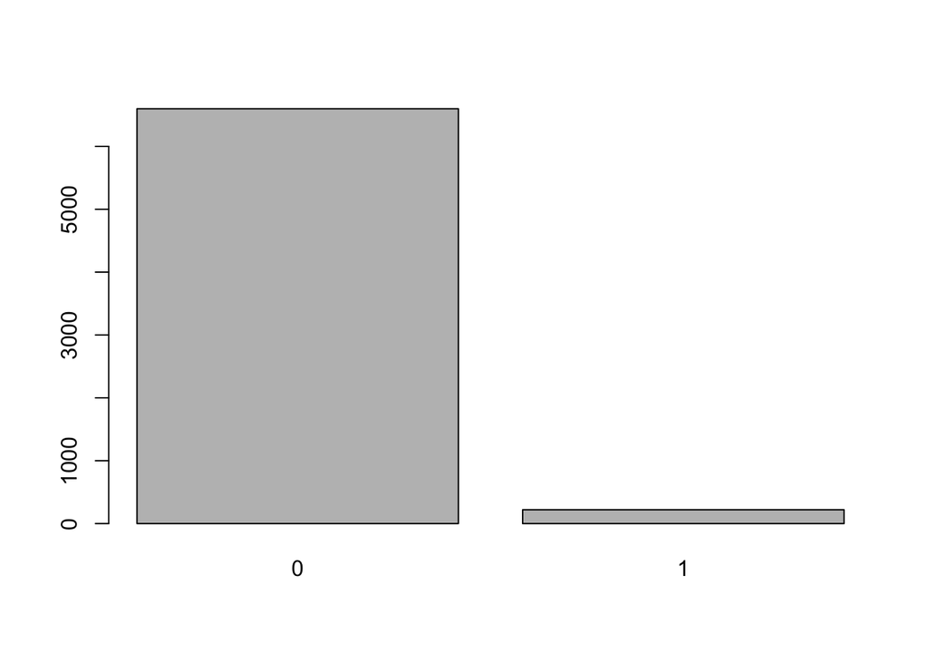

```r
companies$Bankrupt. %>% table() %>% barplot()
```

> Too imbalanced, I’ll upsample the data

### Upsample the data

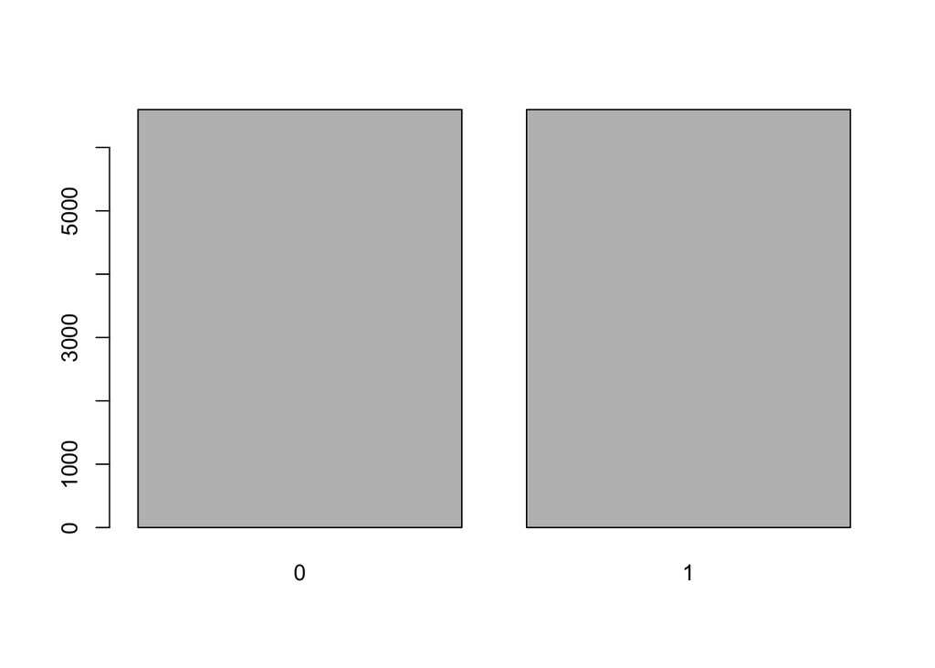

```r
up_companies <- upSample(x = companies %>% select(-Bankrupt.),
                         y = companies$Bankrupt.,
                         yname = "Bankrupt")

up_companies$Bankrupt %>% table() %>% barplot()
```

> Nice. It’s balanced now!

## **Feature Engineering** (with Unsupervised Learning)

### Check features correlations

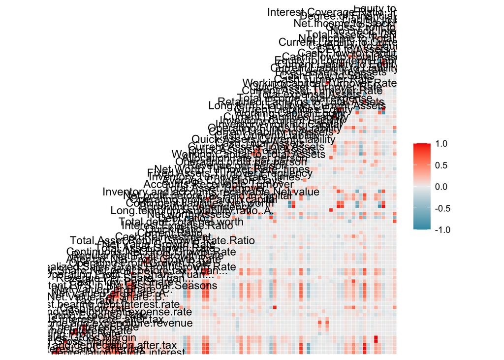

```r
ggcorr(up_companies)
```

> Ah hell nah. There are bunch of correlated features.

> Because there are too many columns, I’ll implement Principal Component Analysis (PCA)!

### Principal Component Analysis (PCA)

```r
pca_companies <- PCA(X = up_companies,
                     scale.unit = T,
                     graph = F,
                     quali.sup = which(colnames(up_companies) == "Bankrupt"),
                     ncp = ncol(up_companies) - 1)
```

## **Feature Selection**

### Check cumulative percentage

```r
pca_companies$eig
```

```
##           eigenvalue percentage of variance cumulative percentage of variance
## comp 1  1.458003e+01           1.567745e+01                          15.67745
## comp 2  7.119303e+00           7.655164e+00                          23.33262
## comp 3  4.686360e+00           5.039097e+00                          28.37171
## comp 4  3.961041e+00           4.259184e+00                          32.63090
## comp 5  3.620691e+00           3.893217e+00                          36.52411
## comp 6  3.026526e+00           3.254329e+00                          39.77844
## comp 7  2.869226e+00           3.085189e+00                          42.86363
## comp 8  2.675507e+00           2.876889e+00                          45.74052
## comp 9  2.622784e+00           2.820198e+00                          48.56072
## comp 10 2.491720e+00           2.679269e+00                          51.23999
## comp 11 2.138641e+00           2.299614e+00                          53.53960
## comp 12 1.846405e+00           1.985382e+00                          55.52498
## comp 13 1.722693e+00           1.852358e+00                          57.37734
## comp 14 1.485455e+00           1.597264e+00                          58.97460
## comp 15 1.451848e+00           1.561127e+00                          60.53573
## comp 16 1.379655e+00           1.483500e+00                          62.01923
## comp 17 1.309361e+00           1.407915e+00                          63.42715
## comp 18 1.273898e+00           1.369783e+00                          64.79693
## comp 19 1.212811e+00           1.304098e+00                          66.10103
## comp 20 1.176381e+00           1.264926e+00                          67.36595
## comp 21 1.141858e+00           1.227804e+00                          68.59376
## comp 22 1.133436e+00           1.218749e+00                          69.81251
## comp 23 1.104190e+00           1.187301e+00                          70.99981
## comp 24 1.065804e+00           1.146026e+00                          72.14583
## comp 25 1.061716e+00           1.141630e+00                          73.28746
## comp 26 1.041052e+00           1.119411e+00                          74.40687
## comp 27 1.025830e+00           1.103043e+00                          75.50992
## comp 28 1.006724e+00           1.082499e+00                          76.59242
## comp 29 1.002591e+00           1.078054e+00                          77.67047
## comp 30 9.978076e-01           1.072911e+00                          78.74338
## comp 31 9.782320e-01           1.051862e+00                          79.79524
## comp 32 9.634694e-01           1.035989e+00                          80.83123
## comp 33 9.516170e-01           1.023244e+00                          81.85448
## comp 34 9.409444e-01           1.011768e+00                          82.86624
## comp 35 9.063638e-01           9.745847e-01                          83.84083
## comp 36 8.939967e-01           9.612868e-01                          84.80212
## comp 37 8.766077e-01           9.425889e-01                          85.74471
## comp 38 8.266622e-01           8.888841e-01                          86.63359
## comp 39 8.046771e-01           8.652442e-01                          87.49883
```

[output cut: 39 more lines]

```
## comp 79 3.293646e-03           3.541555e-03                          99.99050
## comp 80 2.921894e-03           3.141822e-03                          99.99365
## comp 81 2.375983e-03           2.554820e-03                          99.99620
## comp 82 1.205621e-03           1.296366e-03                          99.99750
## comp 83 6.783903e-04           7.294519e-04                          99.99823
## comp 84 5.551237e-04           5.969072e-04                          99.99882
## comp 85 4.103825e-04           4.412715e-04                          99.99926
## comp 86 3.553406e-04           3.820867e-04                          99.99965
## comp 87 3.282632e-04           3.529712e-04                         100.00000
## comp 88 7.082070e-09           7.615129e-09                         100.00000
## comp 89 1.778111e-11           1.911947e-11                         100.00000
## comp 90 1.405168e-18           1.510934e-18                         100.00000
## comp 91 1.772578e-24           1.905998e-24                         100.00000
## comp 92 9.240342e-30           9.935851e-30                         100.00000
## comp 93 4.060072e-31           4.365669e-31                         100.00000
```

> I will accumulate up to 95% of the total information, means I will use up to 50 PCs

```r
pc_companies <- as.data.frame(pca_companies$ind$coord[, 1:50]) %>%
  mutate(Bankrupt = up_companies$Bankrupt)

pc_companies %>% head()
```

|  | Dim.1 | Dim.2 | Dim.3 | Dim.4 | Dim.5 | Dim.6 | Dim.7 | Dim.8 | Dim.9 | Dim.10 | Dim.11 | Dim.12 | Dim.13 | Dim.14 | Dim.15 | Dim.16 | Dim.17 | Dim.18 | Dim.19 | Dim.20 | Dim.21 | Dim.22 | Dim.23 | Dim.24 | Dim.25 | Dim.26 | Dim.27 | Dim.28 | Dim.29 | … |
| --- | --- | --- | --- | --- | --- | --- | --- | --- | --- | --- | --- | --- | --- | --- | --- | --- | --- | --- | --- | --- | --- | --- | --- | --- | --- | --- | --- | --- | --- | --- |
| 1 | -2.5072506 | -0.23792771 | -0.9039606 | 0.05935350 | -0.09303347 | 0.4814731 | 1.6068715 | 1.5442579 | 0.52299794 | -1.2750342 | 0.24021370 | 0.7914640 | -0.7579903 | -0.36178656 | 0.44428791 | -1.27044214 | -0.08632373 | 0.189102601 | -0.04553123 | -0.02550832 | 0.146788727 | 0.1444332 | 0.1756873 | -0.11788482 | -0.1579996 | -0.574695249 | -0.097580114 | -0.1165317 | 0.138472619 | … |
| 2 | 1.6310837 | 0.20474611 | -0.2998072 | 0.58145854 | 1.11523628 | 0.7008220 | -0.7540963 | -0.2431433 | -0.50180752 | 0.3892914 | 0.96727564 | 0.4262827 | -0.6409287 | -0.65537113 | 0.98170284 | -0.84770173 | 1.22466283 | -1.049613393 | 1.32807552 | -0.17050966 | -0.454545424 | -0.6402926 | -0.2218408 | -0.07940746 | 0.1524427 | -0.184604850 | -0.187598037 | 0.6405210 | -0.238397995 | … |
| 3 | 1.6445481 | -0.15980254 | 0.3239394 | -0.18180636 | -0.86095092 | -0.3210848 | -0.4577119 | -0.1508316 | -0.53063608 | 0.2851152 | 0.32727188 | -0.1761818 | -0.1639984 | 0.06124182 | 0.06834129 | 0.01676426 | 1.17443975 | -0.880180867 | 1.40833657 | -0.24721900 | -0.309709024 | -0.0577708 | -0.1023144 | 0.04219805 | 0.2970670 | -0.009251801 | -0.369799525 | 0.3236858 | -0.204759093 | … |
| 4 | 1.7410483 | 0.30074806 | 0.6553860 | 0.55723656 | 1.25579921 | 1.3844599 | -0.9611653 | -0.3121403 | -0.61839957 | 0.5004710 | 0.62387029 | 0.5013370 | -0.9817107 | -0.74968882 | 1.01989939 | -0.93399086 | 0.62051844 | -1.189438839 | 0.90079594 | 0.50874238 | -0.006831742 | -0.2197587 | -0.2677063 | -0.09565150 | -0.2597143 | 0.089393106 | 0.002278874 | 0.8414893 | 0.020679739 | … |
| 5 | 1.1328628 | 0.23721774 | -3.2987984 | 0.08405307 | -0.99309501 | -0.5185606 | 0.5372007 | 0.6720256 | -0.06828677 | -0.8329815 | -0.09761628 | 0.7668831 | -0.9004021 | -0.74105375 | 1.26101207 | -0.36981127 | -0.56489528 | -0.003408939 | 0.48283616 | -0.50351843 | 0.348098961 | -0.7605807 | 0.1325587 | -0.28006765 | 0.5016367 | 0.495496555 | -0.671288008 | -0.4227161 | -0.144198922 | … |
| 6 | 0.9025909 | 0.01936012 | -2.0039230 | -0.23772933 | -1.41584679 | -0.2617335 | 1.2152264 | 1.1618467 | 0.23211765 | -1.0390806 | 0.05349395 | 0.3265396 | -0.8754523 | -0.24406757 | 0.42818379 | -0.94938033 | 0.34291475 | -0.365171045 | 0.42008751 | -0.22966397 | 0.057527443 | -0.1463710 | 0.1092784 | -0.06376738 | 0.4065779 | -0.153397344 | -0.276597648 | 0.2087172 | 0.005218739 | … |

### Check features correlations again

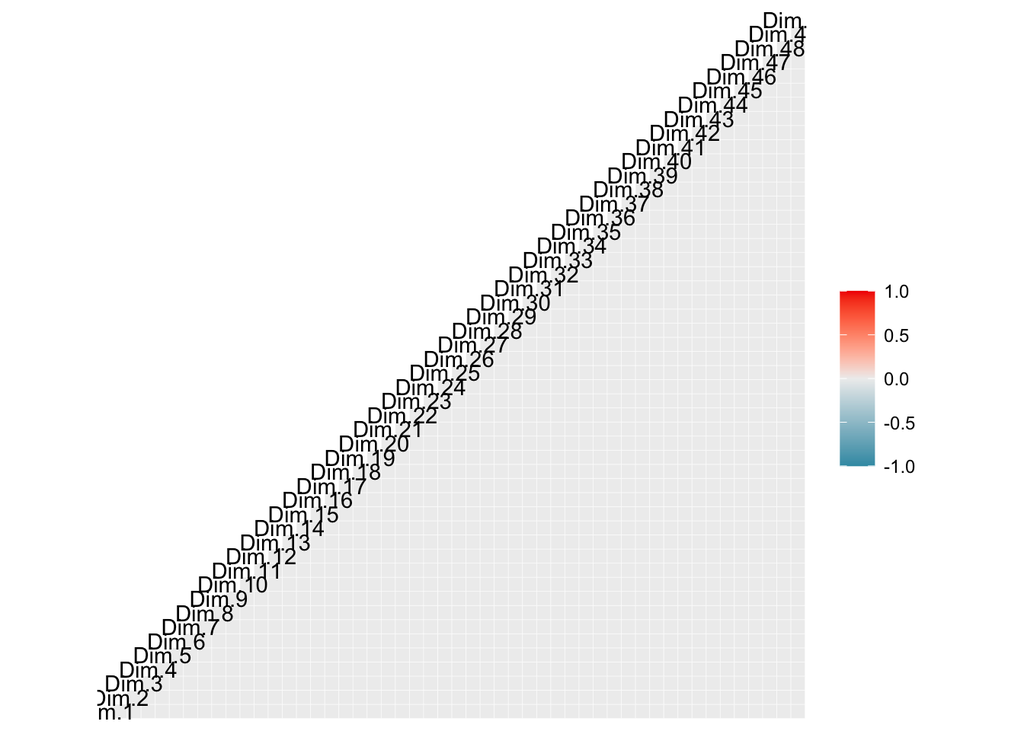

```r
ggcorr(pc_companies)
```

> Magnificent. I now don’t have correlated features. This is the beauty of PCA!

## **Exploratory Data Analysis**

### PC1 vs PC2

#### Variable Factor Map

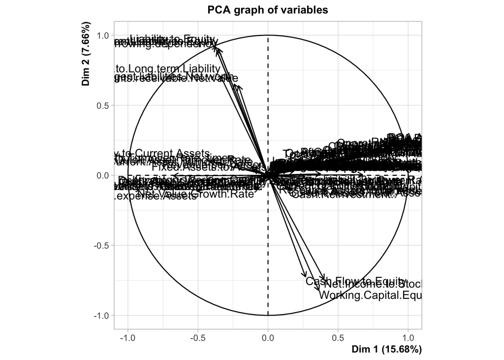

```r
plot.PCA(x = pca_companies,
         choix = "var")
```

#### Individual Factor Map

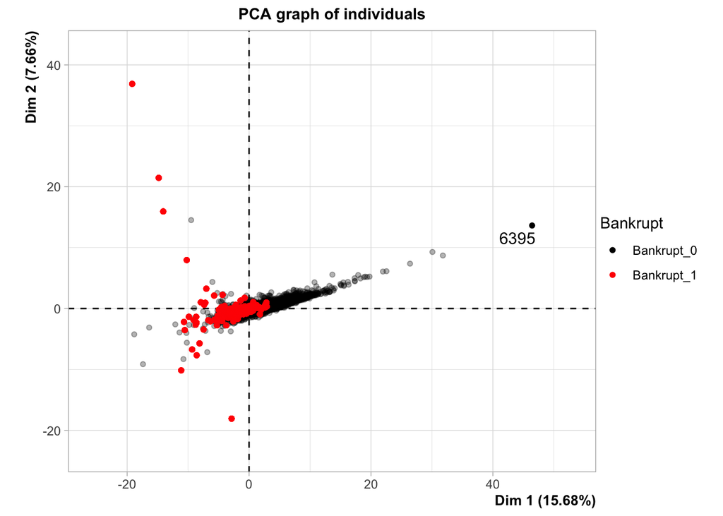

```r
plot.PCA(
  x = pca_companies,
  choix = "ind",
  habillage = "Bankrupt",
  select = "contrib 0",
  invisible = "quali"
)
```

#### Top 5 Contributed Variables

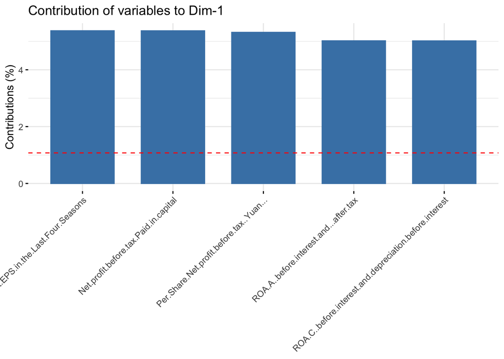

```r
fviz_contrib(pca_companies,
             "var",
             top = 5)
```

## **Cross Validation**

### Set training indices

```r
set.seed(1)

indices <- createDataPartition(y = pc_companies$Bankrupt,
                               p = 0.8,
                               list = FALSE)
```

### Train test split

```r
train_data <- pc_companies[indices, ]
test_data <- pc_companies[-indices, ]

X_train <- train_data %>% select(-Bankrupt)
y_train <- train_data$Bankrupt

X_test <- test_data %>% select(-Bankrupt)
y_test <- test_data$Bankrupt
```

## **Model Fitting**

### Logistic Regression Algorithm

```r
model_lgr <- glm(formula = Bankrupt ~ .,
                 family = "binomial",
                 data = train_data)

model_lgr %>% summary()
```

```
##
## Call:
## glm(formula = Bankrupt ~ ., family = "binomial", data = train_data)
##
## Coefficients:
##               Estimate Std. Error    z value Pr(>|z|)
## (Intercept)  3.139e+14  6.562e+05  4.783e+08   <2e-16 ***
## Dim.1       -2.883e+14  1.743e+05 -1.654e+09   <2e-16 ***
## Dim.2       -4.688e+13  2.383e+05 -1.967e+08   <2e-16 ***
## Dim.3       -1.225e+14  3.035e+05 -4.038e+08   <2e-16 ***
## Dim.4        4.098e+13  3.079e+05  1.331e+08   <2e-16 ***
## Dim.5        5.255e+13  3.421e+05  1.536e+08   <2e-16 ***
## Dim.6       -7.041e+13  3.766e+05 -1.870e+08   <2e-16 ***
## Dim.7        8.677e+13  4.425e+05  1.961e+08   <2e-16 ***
## Dim.8        1.070e+14  4.027e+05  2.656e+08   <2e-16 ***
## Dim.9       -2.530e+13  4.785e+05 -5.287e+07   <2e-16 ***
## Dim.10       1.066e+13  4.177e+05  2.551e+07   <2e-16 ***
## Dim.11       6.728e+12  5.669e+05  1.187e+07   <2e-16 ***
## Dim.12      -6.961e+13  5.264e+05 -1.322e+08   <2e-16 ***
## Dim.13       7.400e+13  5.429e+05  1.363e+08   <2e-16 ***
## Dim.14      -1.794e+14  3.840e+06 -4.672e+07   <2e-16 ***
## Dim.15      -1.143e+14  3.079e+06 -3.712e+07   <2e-16 ***
## Dim.16      -2.294e+14  7.476e+05 -3.069e+08   <2e-16 ***
## Dim.17      -1.506e+14  5.972e+05 -2.522e+08   <2e-16 ***
## Dim.18      -5.329e+13  5.742e+05 -9.281e+07   <2e-16 ***
## Dim.19      -2.213e+14  6.708e+05 -3.300e+08   <2e-16 ***
## Dim.20       4.860e+13  6.416e+05  7.574e+07   <2e-16 ***
## Dim.21      -7.760e+13  6.403e+05 -1.212e+08   <2e-16 ***
## Dim.22       1.019e+14  6.355e+05  1.604e+08   <2e-16 ***
## Dim.23      -3.813e+13  7.173e+05 -5.316e+07   <2e-16 ***
## Dim.24       1.816e+14  6.477e+05  2.804e+08   <2e-16 ***
## Dim.25      -9.701e+13  6.626e+05 -1.464e+08   <2e-16 ***
## Dim.26       6.235e+13  6.402e+05  9.740e+07   <2e-16 ***
## Dim.27       1.023e+13  6.309e+05  1.622e+07   <2e-16 ***
## Dim.28      -8.672e+13  6.564e+05 -1.321e+08   <2e-16 ***
## Dim.29      -7.871e+11  6.366e+05 -1.236e+06   <2e-16 ***
## Dim.30      -3.246e+13  6.366e+05 -5.099e+07   <2e-16 ***
## Dim.31       4.428e+13  6.957e+05  6.365e+07   <2e-16 ***
## Dim.32       2.618e+13  6.925e+05  3.780e+07   <2e-16 ***
## Dim.33      -1.822e+13  7.374e+05 -2.471e+07   <2e-16 ***
```

[output cut: 12 more lines]

```
## Dim.46       1.428e+14  9.191e+05  1.554e+08   <2e-16 ***
## Dim.47       1.119e+13  8.399e+05  1.332e+07   <2e-16 ***
## Dim.48      -8.794e+12  1.419e+06 -6.198e+06   <2e-16 ***
## Dim.49      -2.625e+13  3.727e+06 -7.044e+06   <2e-16 ***
## Dim.50       6.910e+13  3.254e+06  2.124e+07   <2e-16 ***
## ---
## Signif. codes:  0 '***' 0.001 '**' 0.01 '*' 0.05 '.' 0.1 ' ' 1
##
## (Dispersion parameter for binomial family taken to be 1)
##
##     Null deviance:  14639  on 10559  degrees of freedom
## Residual deviance: 144823  on 10509  degrees of freedom
## AIC: 144925
##
## Number of Fisher Scoring iterations: 25
```

### Logistic Regression Model Evaluation

```r
pred_lgr_raw <- predict(model_lgr, X_test, type = "response")
pred_lgr <- ifelse(pred_lgr_raw > 0.5, 1, 0)
```

#### Confusion Matrix

```r
confusionMatrix(as.factor(pred_lgr), y_test)
```

```
## Confusion Matrix and Statistics
##
##           Reference
## Prediction    0    1
##          0  882   76
##          1  437 1243
##
##                Accuracy : 0.8055
##                  95% CI : (0.7899, 0.8205)
##     No Information Rate : 0.5
##     P-Value [Acc > NIR] : < 2.2e-16
##
##                   Kappa : 0.6111
##
##  Mcnemar's Test P-Value : < 2.2e-16
##
##             Sensitivity : 0.6687
##             Specificity : 0.9424
##          Pos Pred Value : 0.9207
##          Neg Pred Value : 0.7399
##              Prevalence : 0.5000
##          Detection Rate : 0.3343
##    Detection Prevalence : 0.3632
##       Balanced Accuracy : 0.8055
##
##        'Positive' Class : 0
##
```

#### AUC of ROC

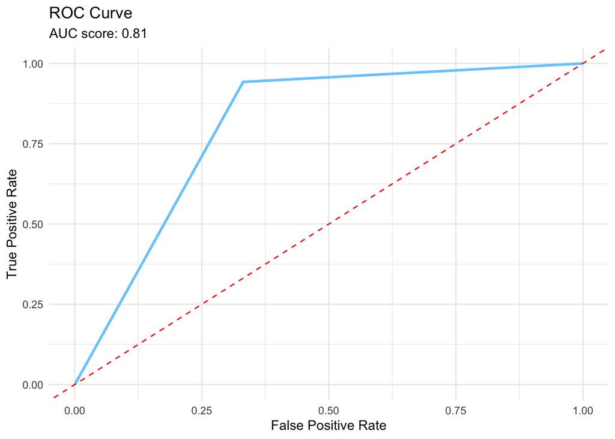

```r
plotROC(pred_lgr_raw, y_test)
```

> Not bad. But let’s try K-Nearest Neighbour algorithm!

### K-Nearest Neighbour Algorithm

```r
pred_knn <- knn(train = X_train,
                test = X_test,
                cl = y_train,
                k = round(sqrt(nrow(X_train))))
```

### KNN Evaluation

```r
confusionMatrix(pred_knn, y_test)
```

```
## Confusion Matrix and Statistics
##
##           Reference
## Prediction    0    1
##          0 1077   91
##          1  242 1228
##
##                Accuracy : 0.8738
##                  95% CI : (0.8605, 0.8862)
##     No Information Rate : 0.5
##     P-Value [Acc > NIR] : < 2.2e-16
##
##                   Kappa : 0.7475
##
##  Mcnemar's Test P-Value : < 2.2e-16
##
##             Sensitivity : 0.8165
##             Specificity : 0.9310
##          Pos Pred Value : 0.9221
##          Neg Pred Value : 0.8354
##              Prevalence : 0.5000
##          Detection Rate : 0.4083
##    Detection Prevalence : 0.4428
##       Balanced Accuracy : 0.8738
##
##        'Positive' Class : 0
##
```